# FinalProject

# 9. FISHER’S EXACT TEST

**Aim:** In this section, I would like to discover if there is an association between having lunch and math scores.

**Hyphotesis:**

- *H0:* Having lunch and being succesfull in math score are independent.
- *H1:* Having lunch and being succesfull in math score are dependent.
- *significant level:* 0.05.

For this test, we will consider the student who has higher than mean score as successful and otherwise not.

```r
mean.math.score <- mean(student_df$math_score)
mean.math.score
```

```
## [1] 66.089
```

```r
student.df.fisher <- student_df
student.df.fisher$math_score<-ifelse(student.df.fisher$math_score >=mean.math.score, "success", "failure")
head(student.df.fisher)
```

```
##   gender race_ethnicity parental_education        lunch test_prep math_score
## 1 female        group B  bachelor's degree     standard      none    success
## 2 female        group C       some college     standard completed    success
## 3 female        group B    master's degree     standard      none    success
## 4   male        group A associate's degree free/reduced      none    failure
## 5   male        group C       some college     standard      none    success
## 6 female        group B associate's degree     standard      none    success
##   reading_score writing_score
## 1            72            74
## 2            90            88
## 3            95            93
## 4            57            44
## 5            78            75
## 6            83            78
```

Let’s plot the bar plot of having lunch(standard) and not(free/reduced) and corresponding math scores and try to spot any correlation.

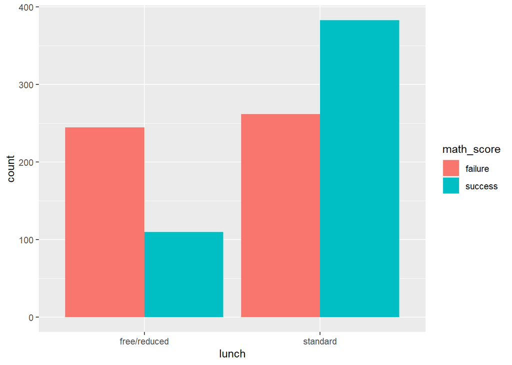

```r
ggplot(student.df.fisher, aes(lunch, ..count..)) + geom_bar(aes(fill = math_score), position = "dodge")
```

It seems that students who has lunch before school are more succesfull in math. But let’s check it if these two feature are dependent or not with Fisher’s test.

```r
fisherTest <- fisher.test(table(student.df.fisher$lunch, student.df.fisher$math_score), conf.int = 0.95)
fisherTest
```

```
##
##  Fisher's Exact Test for Count Data
##
## data:  table(student.df.fisher$lunch, student.df.fisher$math_score)
## p-value < 2.2e-16
## alternative hypothesis: true odds ratio is not equal to 1
## 95 percent confidence interval:
##  2.453082 4.328144
## sample estimates:
## odds ratio
##   3.251817
```

```r
table <- table(student.df.fisher$lunch,
               student.df.fisher$math_score)
table
```

```
##
##                failure success
##   free/reduced     245     110
##   standard         262     383
```

**c. Result:** The p-value of the Fisher Test is: 2.2e-16. Due to its less than our significance level(0.05) we reject the null hypothesis.

**e. Odds Ratio:** The odds ratio shows how many times more positive cases occur than negative cases.

The positive cases in our example are having free/reduced lunch — failure and being having standard lunch — success.

So, this result shows, odds of failure while the student have free/reduced lunch is 3.251817 times more than failure while the student have standard lunch.

# 10. ANOVA and TUKEY TEST

**a. Aim :** Our aim to compare the most often three ethnicity groups of students’ reading scores with prepareation completed and see if the average reading scores of each are equal or not.

**b. Hypothesis and level of significance :**

- *H0:* Mu GroupB.reading.score = Mu GroupC.reading.score = Mu GroupD.reading.score
- *H1:* At least one differs
- *significant level:* 0.05.

**c. Assumption Check :** interval data of the dependent variable normality homoscedasticity no multicollinearity.

*ANOVA*

List the unique ethnicities and their count.

```r
table((student_df$race_ethnicity))
```

```
##
## group A group B group C group D group E
##      89     190     319     262     140
```

It seems that most often ethnicities are *Group B*, *Group C* and *Group D*. Let’s just take these three groups of ethnicty and their reading score with preperation.

```r
reading.groupB= subset(student_df, subset = race_ethnicity == "group B" & test_prep == "completed")
reading.groupC = subset(student_df, subset = race_ethnicity == "group C" & test_prep == "completed")
reading.groupD = subset(student_df, subset = race_ethnicity == "group D" & test_prep == "completed")

head(reading.groupB)
```

```
##     gender race_ethnicity parental_education        lunch test_prep math_score
## 7   female        group B       some college     standard completed         88
## 22  female        group B       some college free/reduced completed         65
## 44    male        group B       some college free/reduced completed         59
## 97    male        group B   some high school     standard completed         65
## 104   male        group B        high school     standard completed         60
## 122   male        group B associate's degree     standard completed         91
##     reading_score writing_score
## 7              95            92
## 22             75            70
## 44             65            66
## 97             66            62
## 104            44            47
## 122            89            92
```

Now visualize them and see if the data normally distributed or not.

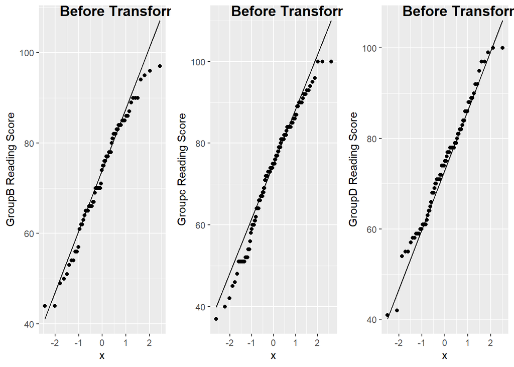

```r
p1 <- ggplot(reading.groupB, aes(sample = reading_score)) + ylab("GroupB Reading Score") +
  stat_qq() +
  stat_qq_line()

p2 <- ggplot(reading.groupC, aes(sample = reading_score)) + ylab("Groupc Reading Score") +
  stat_qq() +
  stat_qq_line()

p3 <- ggplot(reading.groupD, aes(sample = reading_score)) + ylab("GroupD Reading Score") +
  stat_qq() +
  stat_qq_line()

ggarrange(p1, p2, p3, ncol =3, nrow = 1, labels = c( "Before Transform","Before Transform",
                                                 "Before Transform"))
```

It seems that data are normally distiributed but let’s take a Shapiro Test of each one.

```r
shapiro.test(reading.groupB$reading_score)
```

```
##
##  Shapiro-Wilk normality test
##
## data:  reading.groupB$reading_score
## W = 0.977, p-value = 0.2408
```

```r
shapiro.test(reading.groupC$reading_score)
```

```
##
##  Shapiro-Wilk normality test
##
## data:  reading.groupC$reading_score
## W = 0.9738, p-value = 0.02162
```

```r
shapiro.test(reading.groupD$reading_score)
```

```
##
##  Shapiro-Wilk normality test
##
## data:  reading.groupD$reading_score
## W = 0.98533, p-value = 0.4763
```

**Note:** Group B and Group D has p-value bigger than 0.05 and that means these two groups’ score are normally distributed but Group C is not. For the following tests we’ll assume that also the reading score of Group C is normally distributed.

Due to we assume that the data is normally distributed now we can compute the ANOVA test.

- *H0:* Mu GroupB.reading.score = Mu GroupC.reading.score = Mu GroupD.reading.score
- *H1:* At least one differs

```r
#Prepare the data for ANOVA
group.BCD.reading.score <- subset(student_df, subset = (race_ethnicity == "group B" | race_ethnicity == "group C" | race_ethnicity == "group D") & test_prep == "completed")

head(group.BCD.reading.score)
```

```
##    gender race_ethnicity parental_education        lunch test_prep math_score
## 2  female        group C       some college     standard completed         69
## 7  female        group B       some college     standard completed         88
## 9    male        group D        high school free/reduced completed         64
## 19   male        group C    master's degree free/reduced completed         46
## 22 female        group B       some college free/reduced completed         65
## 25   male        group D  bachelor's degree free/reduced completed         74
##    reading_score writing_score
## 2             90            88
## 7             95            92
## 9             64            67
## 19            42            46
## 22            75            70
## 25            71            80
```

```r
# Compute the analysis of variance
res.aov <- aov(reading_score ~ race_ethnicity, data = group.BCD.reading.score)
# Summary of the analysis
summary(res.aov)
```

```
##                 Df Sum Sq Mean Sq F value Pr(>F)
## race_ethnicity   2     63   31.41   0.175  0.839
## Residuals      264  47319  179.24
```

**d. Result of ANOVA:** The p-value obtained from ANOVA is 0.839 and bigger than alpha(0.05): The differences between the means are not statistically significant. There is not enough evidence to reject the null hypothesis.

*TUKEY*

This test tells us which pairs of groups are significantly different. We find that there is not significantly difference in our pair of groups. But let’s compute the Tukey Test and see it better.

```r
TukeyHSD(res.aov)
```

```
##   Tukey multiple comparisons of means
##     95% family-wise confidence level
##
## Fit: aov(formula = reading_score ~ race_ethnicity, data = group.BCD.reading.score)
##
## $race_ethnicity
##                      diff       lwr      upr     p adj
## group C-group B 0.8051785 -4.006716 5.617073 0.9178659
## group D-group B 1.2934003 -3.882214 6.469015 0.8261293
## group D-group C 0.4882218 -4.056469 5.032913 0.9652791
```

# 11. Multiple Linear Regression

**a. Aim :** Building a model for estimating score based on the parental_education, test_prep, gender, race_ethnicity and lunch groups.

**b. Regression Equation :** score = b0 + b1xparental_education + b2xtest_prep + b3xlunch + b4xgender + b5*race_ethnicity

**c. Hypothesis and level of significance :**

- *H0:* β1 = β2 = … = βk = 0(there is no (linear) relationship between the three variables)
- *H1:* βj ≠ 0 for at least one j(there is a (linear) relationship between the three variables)
- *significant level:* 0.05.

**d. Find the Best Model :**

```r
model <- lm(score ~ parental_education + test_prep + lunch + gender + race_ethnicity, data = Data_gather)
summary(model)
```

```
##
## Call:
## lm(formula = score ~ parental_education + test_prep + lunch +
##     gender + race_ethnicity, data = Data_gather)
##
## Residuals:
##     Min      1Q  Median      3Q     Max
## -57.148  -9.074   0.896   9.434  32.745
##
## Coefficients:
##                                     Estimate Std. Error t value Pr(>|t|)
## (Intercept)                          66.9408     1.0939  61.196  < 2e-16 ***
## parental_educationbachelor's degree   2.5356     0.8776   2.889 0.003890 **
## parental_educationhigh school        -5.1725     0.7579  -6.825 1.06e-11 ***
## parental_educationmaster's degree     4.0922     1.1325   3.613 0.000307 ***
## parental_educationsome college       -0.9275     0.7286  -1.273 0.203134
## parental_educationsome high school   -4.5400     0.7789  -5.828 6.19e-09 ***
## test_prepnone                        -7.6386     0.5116 -14.929  < 2e-16 ***
## lunchstandard                         8.7751     0.5099  17.208  < 2e-16 ***
## gendermale                           -3.7242     0.4902  -7.597 4.04e-14 ***
## race_ethnicitygroup B                 1.5290     0.9932   1.539 0.123799
## race_ethnicitygroup C                 2.3855     0.9301   2.565 0.010375 *
## race_ethnicitygroup D                 5.1258     0.9490   5.401 7.13e-08 ***
## race_ethnicitygroup E                 6.9285     1.0527   6.582 5.47e-11 ***
## ---
## Signif. codes:  0 '***' 0.001 '**' 0.01 '*' 0.05 '.' 0.1 ' ' 1
##
## Residual standard error: 13.33 on 2987 degrees of freedom
## Multiple R-squared:  0.2176, Adjusted R-squared:  0.2145
## F-statistic: 69.24 on 12 and 2987 DF,  p-value: < 2.2e-16
```

The t-statistic evaluates whether or not there is significant association between the predictor and the outcome variable, that is whether the beta coefficient of the predictor is significantly different from zero.

```r
model <- lm(score ~  lunch +  race_ethnicity, data = Data_gather)
summary(model)
```

```
##
## Call:
## lm(formula = score ~ lunch + race_ethnicity, data = Data_gather)
##
## Residuals:
##     Min      1Q  Median      3Q     Max
## -61.746  -9.218   0.254   9.873  36.869
##
## Coefficients:
##                       Estimate Std. Error t value Pr(>|t|)
## (Intercept)            58.0020     0.9309  62.305  < 2e-16 ***
## lunchstandard           8.3803     0.5449  15.379  < 2e-16 ***
## race_ethnicitygroup B   2.1295     1.0576   2.014 0.044145 *
## race_ethnicitygroup C   3.7442     0.9871   3.793 0.000152 ***
## race_ethnicitygroup D   5.8358     1.0102   5.777 8.39e-09 ***
## race_ethnicitygroup E   8.8243     1.1176   7.896 4.02e-15 ***
## ---
## Signif. codes:  0 '***' 0.001 '**' 0.01 '*' 0.05 '.' 0.1 ' ' 1
##
## Residual standard error: 14.26 on 2994 degrees of freedom
## Multiple R-squared:  0.1026, Adjusted R-squared:  0.1011
## F-statistic: 68.45 on 5 and 2994 DF,  p-value: < 2.2e-16
```

Finally, our model equation can be written as follow: *score = 58 + 8.3xlunchstandard + 2.1xrace_ethnicitygroup B + 3.7xrace_ethnicitygroup C + 5.8xrace_ethnicitygroup D + 8.8xrace_ethnicitygroup E*

The confidence interval of the model coefficient can be extracted as follow:

```r
confint(model)
```

```
##                             2.5 %    97.5 %
## (Intercept)           56.17662382 59.827311
## lunchstandard          7.31187198  9.448816
## race_ethnicitygroup B  0.05583966  4.203156
## race_ethnicitygroup C  1.80869803  5.679715
## race_ethnicitygroup D  3.85501358  7.816491
## race_ethnicitygroup E  6.63296499 11.015661
```

The overall quality of the model can be assessed by examining the R-squared (R2) and Residual Standard Error (RSE).

**Residual Standard Error (RSE), or sigma**

The RSE estimate gives a measure of error of prediction. The lower the RSE, the more accurate the model (on the data in hand).

The error rate can be estimated by dividing the RSE by the mean outcome variable:

```r
sigma(model)/mean(Data_gather$score)
```

```
## [1] 0.2103795
```

In our multiple regression example, the RSE is 14.26 corresponding to 21% error rate.

**e. Assumption Check :** Linear relationship Multivariate normality No auto-correlation No or little multicollinearity Homoscedasticity

**h. Prediction :**

```r
#define new student
new <- data.frame(lunch=c("standard"), race_ethnicity=c("group A"))

#use the fitted model to predict the score for the new student
predict(model, newdata=new)
```

```
##        1
## 66.38231
```